# ST117 Individual DRAFT Written Report - Part EDA

My WARWICK ID 5645242 (Report Pod 041)

2025-04-08

- For the final submission 20% of the total credit is dedicated to style.
- For the final submission you will also have to adhere to page, word, and figure limits (see separate templates posted later), but the individual DRAFT this is not yet monitored.
- Please do not include the raw data sets in your submission. (Of course, a few lines of raw data are fine.)
- We put together some generic examples of code chunks for initial steps and data visualisation (see at the end of this file). The references to online sources may be worth exploring further if you are looking for ideas about how to visually represent data.
- Please remove the generic examples before you submit and replace them by your own work.
- Remember that you are responsible for everything that you submit even if you used any tools or resources to help you complete your coursework.
- You expected to be able to walk others through your calculations, reasoning, and R code explaining the rationale for each step.
- Your course handbooks contain “AI Guidance for Statistics modules” in Section 5.3., and policy about academic integrity in Section 5.4. Course handbooks are available from Moodle (Statistics > ST_Handbooks).

# Step 5 Summary of aspects of the datasets that are most relevant for statistical analyses

## *Upper limit: 1 page of text (or about 1/3 page per dataset)*

## Stream water chemistry data (1992-2015)

### When, Where and How was the data collected

Dip samples are used to measure the stream water chemistry and are collected weekly. (specific date, hour and minute will be included in the Supporting Documentation)

The data is collected at designated ECN sites across the UK, representing different landscapes and ecosystems. (Including T02:Glensaugh, T04: Moor House - Upper Teesdale, T05: North Wyke, T06: Rothamsted, T07: Sourhope, T08: Wytham, T11: Y Wyddfa – Snowdon, T12: Cairngorms)

Samples are sent to accredited laboratories for chemical analysis. Measured variables include: nutrients (nitrate, ammonium, phosphate), metals (iron, aluminium), pH, Conductivity etc.

As a quality check, a standard quality control solution is sent to the laboratories that analyse the ECN water samples. This solution is analysed alongside the samples collected in the field.

Multiple levels of quality control were applied: Quality Codes

### Why was the data collected

Monitor water quality over time: by tracking concentrations of key chemical molecules. This detects long term trand and seasonal change within UK and for different UK sites. This could also monitor the health of ecosystem and pollution level which would be able to aid regulatory and policy makings.

## Precipitation chemistry data (1992-2015)

### When, Where and How was the data collected

Bulk collectors are used to measure the precipitation chemistry. The samples are collected weekly. The data was collected weekly spanning 1992 to 2015. (specific date, hour and minute will be included in the Supporting Documentation)

The data was collected from 12 terrestrial ECN sites across the UK, including upland and lowland regions. This includes Drayton, Glensaugh, Hillsborough, Moor House – Upper Teesdale, North Wyke, Rothamsted, Sourhope, Wytham, Alice Holt, Porton Down, Y Wyddfa – Snowdon, Cairngorms, with site codes T01 to T12 respectively.

Samples were analysed for a wide range of chemical variables including major cations and anions (such as [Ca²⁺], [Mg²⁺], [NH₄⁺], [NO₃⁻], [SO₄²⁻]), and dissolved molecules (e.g. phosphate).

As a quality check, a standard quality control solution is sent to the laboratories that analyse the ECN water samples. This solution is analysed alongside the samples collected in the field.

Multiple levels of quality control were applied: Quality Codes

### Why was the data collected

The data is able tto help us to identify atmospheric pollution level and trends by monitoring the deposition of pollutants.

It also support long-term environmental monitoring as it provides a long term yet consistent data regarding the eco-system which could help policy makers to evaluate the severity of climate change and take this information into consideration.

## Soil solution chemistry data (1992-2015)

### When, Where and How was the data collected

Suction samplers are used to measure the soil solution chemistry. The samples are collected fortnightly.

Occasionally suction samplers need to be replaced. This will be indicated by a new RID (replicate ID) in the dataset.

If insufficient sample is collected by the individual samplers, then the samples for that sampling day can be bulked. This will be indicated by the RID – ‘XXS’ for shallow samplers and ‘XXD’ for deep samplers.

Key variables measured include: nutrients (NO₃N, NH₄N) metals (Aluminium, Iron) pH, DOC, conductivity residual vacuum, and more.

As a quality check, a standard quality control solution is sent to the laboratories that analyse the ECN water samples. This solution is analysed alongside the samples collected in the field.

The data was collected from 12 terrestrial ECN sites across the UK, including upland and lowland regions. This includes Drayton, Glensaugh, Hillsborough, Moor House – Upper Teesdale, North Wyke, Rothamsted, Sourhope, Wytham, Alice Holt, Porton Down, Y Wyddfa – Snowdon, Cairngorms, with site codes T01 to T12 respectively.

### Why was the data collected

To monitor the long term change in soil water chemistry, including chemical pollution, soil health, potentially for agrculture by using consistent standard methods. To study the affects caused by potential land use changes, xlimate change, acidification etc. to support government policy.

# Step 6: Diagrams about data structure

Your electronic image file can be drawn by any software package, on a tablet, or it can be a photograph of a pencil and paper drawing.

In the R chunks below you need to include the names of your file and remove the hashtags to run.

## Stream water

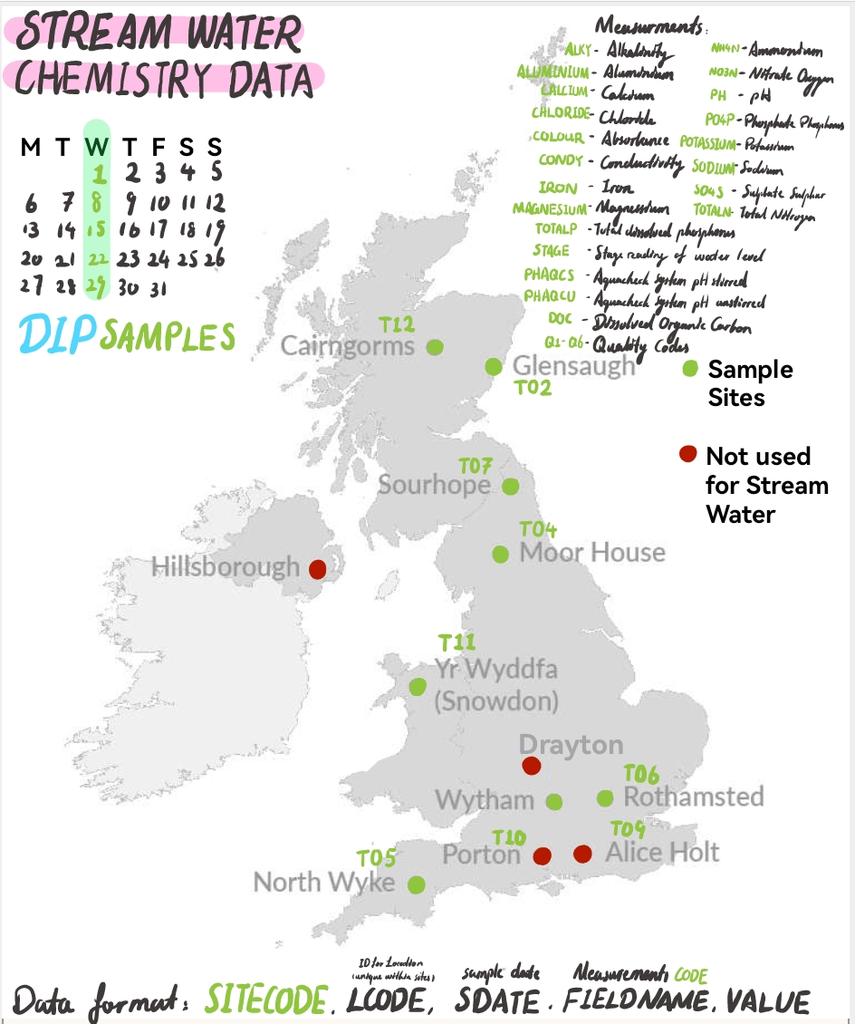

```r
knitr::include_graphics("/Users/danielguo/Desktop/University/Year 1/ST117/5645242_041_WR/Phase 1 Diagram/Stream_Water_Diagram.jpg")
```

## Precipitation

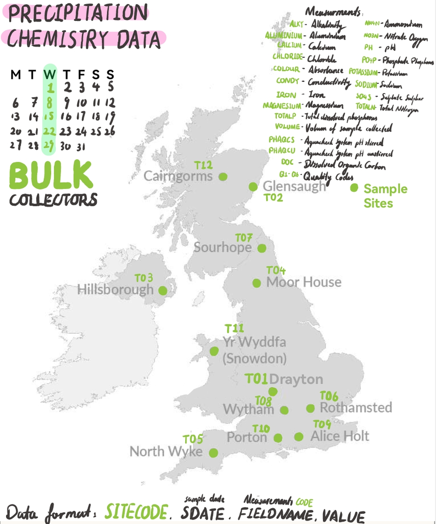

```r
knitr::include_graphics("/Users/danielguo/Desktop/University/Year 1/ST117/5645242_041_WR/Phase 1 Diagram/Precipitation_Diagram.jpg")
```

## Soil solution

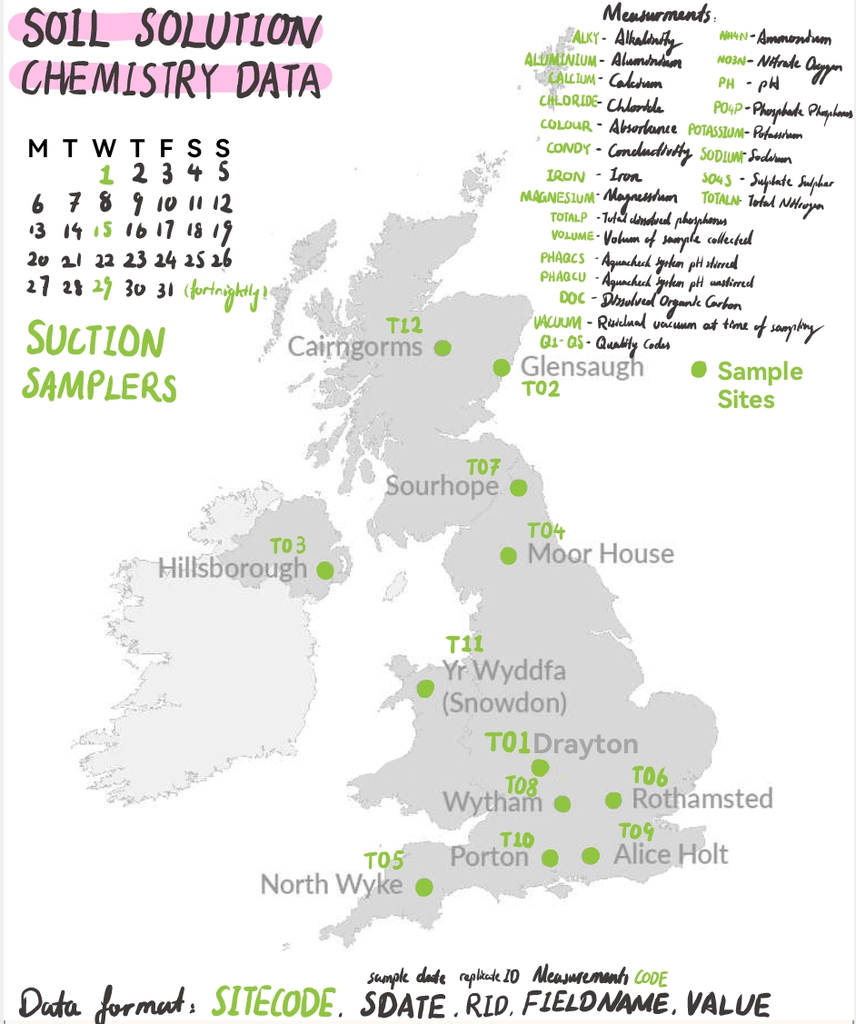

```r
knitr::include_graphics("/Users/danielguo/Desktop/University/Year 1/ST117/5645242_041_WR/Phase 1 Diagram/Soil_Solution_Diagram.jpg")
```

# Step 7: Data loading and preprocessing

```r
library(tidyverse)
#read and create individual data frames for each chemistry data:
df_stream <- read.csv("/Users/danielguo/Desktop/University/Year 1/ST117/5645242_041_WR/data/Stream water/ECN_WC1.csv")
df_precipitation <- read.csv("/Users/danielguo/Desktop/University/Year 1/ST117/5645242_041_WR/data/Precipitation/ECN_PC1.csv")
df_soil <- read.csv("/Users/danielguo/Desktop/University/Year 1/ST117/5645242_041_WR/data/Soil solution/ECN_SS1.csv")

#remove the irrelevant variable for this assignment for stream water data
columns_to_remove_wc <- c("Q1", "Q2", "Q3", "Q4", "Q5", "Q6", "COLOUR")
df_stream_wide <- df_stream %>%
  pivot_wider(
    names_from = FIELDNAME,
    values_from = VALUE
  ) %>%
  select(-all_of(columns_to_remove_wc)) #converting the dataframe to a format showing them as separate columns.
df_stream_wide <- df_stream_wide %>%
  mutate(SDATE = dmy(SDATE)) #converting the date format for easier later use
head(df_stream_wide) #print the first few rows
```

```
## # A tibble: 6 × 23
##   SITECODE LCODE SDATE      ALUMINIUM TOTALN CHLORIDE   DOC  IRON MAGNESIUM
##   <chr>    <int> <date>         <dbl>  <dbl>    <dbl> <dbl> <dbl>     <dbl>
## 1 T04          3 1992-10-06      0.04   0.28      3.9  10.3  0.53      0.9
## 2 T04          1 1992-10-06      0.16   0.55      3.4  16    0.93      0.59
## 3 T04          2 1992-10-06      0.1    0.5       3.6  19.9  0.82      0.31
## 4 T04          3 1992-10-15      0.06   0.31      4.4  11.7  0.45      0.68
## 5 T04          1 1992-10-15      0.12   0.41      4.2  15    0.71      0.44
## 6 T04          2 1992-10-15      0.1    0.4       4.2  16.6  0.52      0.33
## # ℹ 14 more variables: NH4N <dbl>, NO3N <dbl>, PH <dbl>, PO4P <dbl>,
## #   POTASSIUM <dbl>, SO4S <dbl>, SODIUM <dbl>, STAGE <dbl>, CALCIUM <dbl>,
## #   PHAQCS <dbl>, PHAQCU <dbl>, ALKY <dbl>, CONDY <dbl>, TOTALP <dbl>
```

```r
#same process will be applied for the other two dataframes:
columns_to_remove_pc <- c("Q1", "Q2", "Q3", "Q4", "Q5", "Q6", "COLOUR")
df_precipitation_wide <- df_precipitation %>%
  pivot_wider(
    names_from = FIELDNAME,
    values_from = VALUE
  ) %>%
  select(-all_of(columns_to_remove_pc))
df_precipitation_wide <- df_precipitation_wide %>%
  mutate(SDATE = dmy(SDATE))
head(df_precipitation_wide)
```

```
## # A tibble: 6 × 22
##   SITECODE SDATE      VOLUME ALUMINIUM SODIUM   SO4S POTASSIUM  PO4P    PH  NO3N
##   <chr>    <date>      <dbl>     <dbl>  <dbl>  <dbl>     <dbl> <dbl> <dbl> <dbl>
## 1 T04      1992-10-06    611         0   0.34  0.5        0.05     0  4.61  0.3
## 2 T04      1992-10-15    467         0   2.1   0.59       0.1      0  4.97  0.11
## 3 T04      1992-10-21     63         0   3.68  0.75       0.16     0  4.74  0.26
## 4 T04      1992-10-28    842         0   0.7   0.34       0.05     0  4.9   0.11
## 5 T06      1992-10-28    358        NA   1.08  0.613      0       NA  4.56  0.12
## 6 T08      1992-10-28    332        NA  NA    NA         NA       NA NA    NA
## # ℹ 12 more variables: NH4N <dbl>, MAGNESIUM <dbl>, IRON <dbl>, DOC <dbl>,
## #   CHLORIDE <dbl>, CALCIUM <dbl>, TOTALN <dbl>, PHAQCS <dbl>, PHAQCU <dbl>,
## #   CONDY <dbl>, ALKY <dbl>, TOTALP <dbl>
```

```r
columns_to_remove_ss <- c("Q1", "Q2", "Q3", "Q4", "Q5", "COLOUR")
df_soil_wide <- df_soil %>%
  pivot_wider(
    names_from = FIELDNAME,
    values_from = VALUE
  ) %>%
  select(-all_of(columns_to_remove_ss))
df_soil_wide <- df_soil_wide %>%
  mutate(SDATE = dmy(SDATE))
head(df_soil_wide)
```

```
## # A tibble: 6 × 24
##   SITECODE SDATE      RID   VACUUM VOLUME  SO4S SODIUM TOTALN ALUMINIUM CALCIUM
##   <chr>    <date>     <chr>  <dbl>  <dbl> <dbl>  <dbl>  <dbl>     <dbl>   <dbl>
## 1 T04      1992-10-06 A3D     0.27    360    NA     NA     NA        NA      NA
## 2 T04      1992-10-06 F4S     0.16    500    NA     NA     NA        NA      NA
## 3 T04      1992-10-06 A3S     0.24    390    NA     NA     NA        NA      NA
## 4 T04      1992-10-06 B1D     0.23    410    NA     NA     NA        NA      NA
## 5 T04      1992-10-06 B1S     0.12    540    NA     NA     NA        NA      NA
## 6 T04      1992-10-06 C5D     0.21    440    NA     NA     NA        NA      NA
## # ℹ 14 more variables: CHLORIDE <dbl>, DOC <dbl>, IRON <dbl>, MAGNESIUM <dbl>,
## #   NH4N <dbl>, NO3N <dbl>, PH <dbl>, PO4P <dbl>, POTASSIUM <dbl>,
## #   PHAQCS <dbl>, PHAQCU <dbl>, ALKY <dbl>, CONDY <dbl>, TOTALP <dbl>
```

# Step 8: DQA (Data Quality Analysis)

## Uniqueness

```r
# Check for uniqueness: find the number of duplicated rows
sum(duplicated(df_stream_wide))
```

```
## [1] 0
```

```r
sum(duplicated(df_precipitation_wide))
```

```
## [1] 0
```

```r
sum(duplicated(df_soil_wide))
```

```
## [1] 0
```

## Timeliness

```r
# Check for timeliness: sample date range and frequency
library(lubridate)

range(df_stream_wide$SDATE, na.rm = TRUE) #Finding the range for stream water sample dates
```

```
## [1] "1992-10-06" "2015-12-31"
```

```r
range(df_precipitation_wide$SDATE, na.rm = TRUE) #Finding the range for precipitation sample dates
```

```
## [1] "1992-10-06" "2015-12-31"
```

```r
range(df_soil_wide$SDATE, na.rm = TRUE) #Finding the range for soil solution sample dates
```

```
## [1] "1992-10-06" "2015-12-23"
```

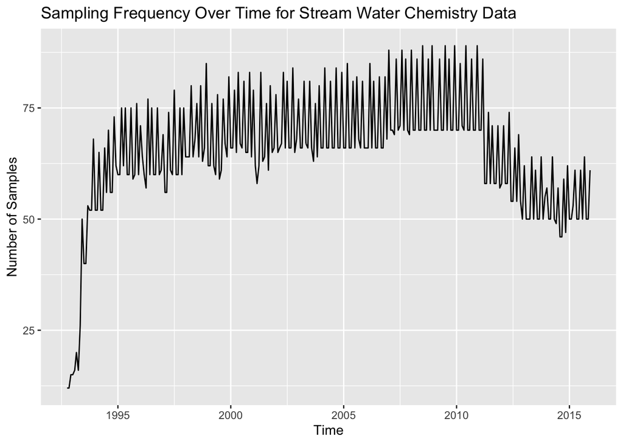

```r
df_stream_wide %>%
  # Create a new column "Month" by extracting the year and month from the SDATE column
  mutate(Month = format(SDATE, "%Y-%m")) %>%
  # Count the number of records for each Month value
  count(Month) %>%
  # Create a line plot using ggplot2
  ggplot(aes(x = as.Date(paste0(Month, "-01")), y = n)) +
  # Plot the number of samples as a line over time
  geom_line() +
  #labels
  labs(title = "Sampling Frequency Over Time for Stream Water Chemistry Data", x = "Time", y = "Number of Samples")
```

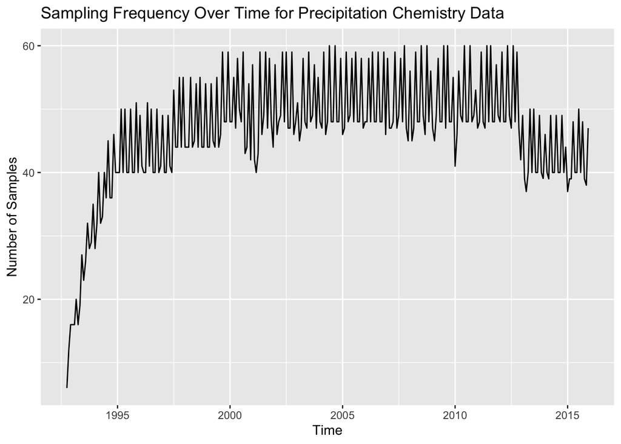

```r
#Same process is used for the other two data frames
df_precipitation_wide %>%
  mutate(Month = format(SDATE, "%Y-%m")) %>%
  count(Month) %>%
  ggplot(aes(x = as.Date(paste0(Month, "-01")), y = n)) +
  geom_line() +
  labs(title = "Sampling Frequency Over Time for Precipitation Chemistry Data", x = "Time", y = "Number of Samples")
```

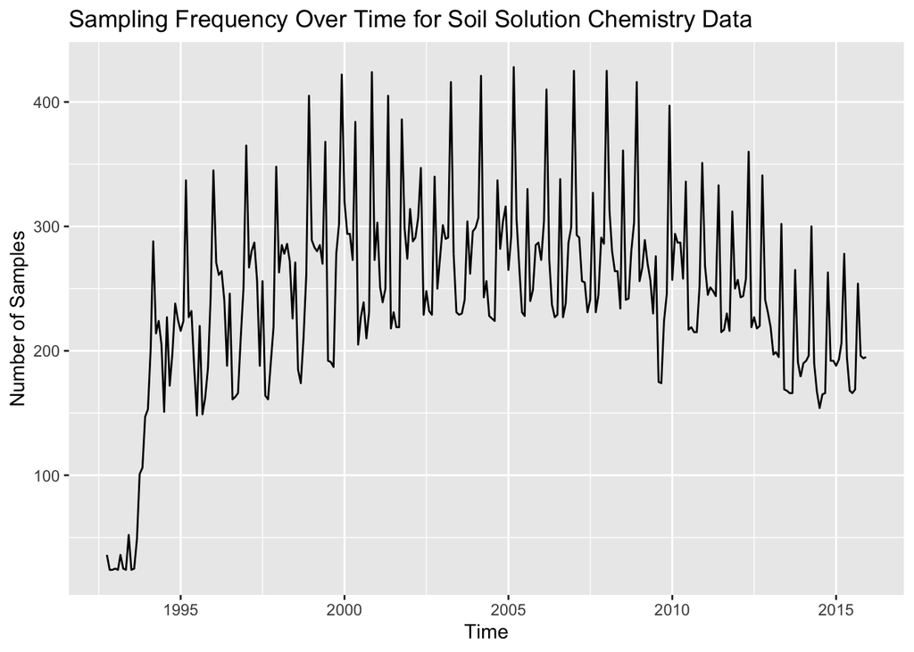

```r
df_soil_wide %>%
  mutate(Month = format(SDATE, "%Y-%m")) %>%
  count(Month) %>%
  ggplot(aes(x = as.Date(paste0(Month, "-01")), y = n)) +
  geom_line() +
  labs(title = "Sampling Frequency Over Time for Soil Solution Chemistry Data", x = "Time", y = "Number of Samples")
```

```r
# Check for Validity:
#Check for dates before 1992 or after 2015 for all data frames
df_stream_wide %>%
  filter(SDATE < as.Date("1992-01-01") | SDATE > as.Date("2015-12-31"))
```

```
## # A tibble: 0 × 23
## # ℹ 23 variables: SITECODE <chr>, LCODE <int>, SDATE <date>, ALUMINIUM <dbl>,
## #   TOTALN <dbl>, CHLORIDE <dbl>, DOC <dbl>, IRON <dbl>, MAGNESIUM <dbl>,
## #   NH4N <dbl>, NO3N <dbl>, PH <dbl>, PO4P <dbl>, POTASSIUM <dbl>, SO4S <dbl>,
## #   SODIUM <dbl>, STAGE <dbl>, CALCIUM <dbl>, PHAQCS <dbl>, PHAQCU <dbl>,
## #   ALKY <dbl>, CONDY <dbl>, TOTALP <dbl>
```

```r
df_precipitation_wide %>%
  filter(SDATE < as.Date("1992-01-01") | SDATE > as.Date("2015-12-31"))
```

```
## # A tibble: 0 × 22
## # ℹ 22 variables: SITECODE <chr>, SDATE <date>, VOLUME <dbl>, ALUMINIUM <dbl>,
## #   SODIUM <dbl>, SO4S <dbl>, POTASSIUM <dbl>, PO4P <dbl>, PH <dbl>,
## #   NO3N <dbl>, NH4N <dbl>, MAGNESIUM <dbl>, IRON <dbl>, DOC <dbl>,
## #   CHLORIDE <dbl>, CALCIUM <dbl>, TOTALN <dbl>, PHAQCS <dbl>, PHAQCU <dbl>,
## #   CONDY <dbl>, ALKY <dbl>, TOTALP <dbl>
```

```r
df_soil_wide %>%
  filter(SDATE < as.Date("1992-01-01") | SDATE > as.Date("2015-12-31"))
```

```
## # A tibble: 0 × 24
## # ℹ 24 variables: SITECODE <chr>, SDATE <date>, RID <chr>, VACUUM <dbl>,
## #   VOLUME <dbl>, SO4S <dbl>, SODIUM <dbl>, TOTALN <dbl>, ALUMINIUM <dbl>,
## #   CALCIUM <dbl>, CHLORIDE <dbl>, DOC <dbl>, IRON <dbl>, MAGNESIUM <dbl>,
## #   NH4N <dbl>, NO3N <dbl>, PH <dbl>, PO4P <dbl>, POTASSIUM <dbl>,
## #   PHAQCS <dbl>, PHAQCU <dbl>, ALKY <dbl>, CONDY <dbl>, TOTALP <dbl>
```

```r
# Check for any pH values below 0 or above 14
df_stream_wide %>% filter(PH < 0 | PH > 14)
```

```
## # A tibble: 0 × 23
## # ℹ 23 variables: SITECODE <chr>, LCODE <int>, SDATE <date>, ALUMINIUM <dbl>,
## #   TOTALN <dbl>, CHLORIDE <dbl>, DOC <dbl>, IRON <dbl>, MAGNESIUM <dbl>,
## #   NH4N <dbl>, NO3N <dbl>, PH <dbl>, PO4P <dbl>, POTASSIUM <dbl>, SO4S <dbl>,
## #   SODIUM <dbl>, STAGE <dbl>, CALCIUM <dbl>, PHAQCS <dbl>, PHAQCU <dbl>,
## #   ALKY <dbl>, CONDY <dbl>, TOTALP <dbl>
```

```r
df_precipitation_wide %>% filter(PH < 0 | PH > 14)
```

```
## # A tibble: 0 × 22
## # ℹ 22 variables: SITECODE <chr>, SDATE <date>, VOLUME <dbl>, ALUMINIUM <dbl>,
## #   SODIUM <dbl>, SO4S <dbl>, POTASSIUM <dbl>, PO4P <dbl>, PH <dbl>,
## #   NO3N <dbl>, NH4N <dbl>, MAGNESIUM <dbl>, IRON <dbl>, DOC <dbl>,
## #   CHLORIDE <dbl>, CALCIUM <dbl>, TOTALN <dbl>, PHAQCS <dbl>, PHAQCU <dbl>,
## #   CONDY <dbl>, ALKY <dbl>, TOTALP <dbl>
```

```r
df_soil_wide %>% filter(PH < 0 | PH > 14)
```

```
## # A tibble: 0 × 24
## # ℹ 24 variables: SITECODE <chr>, SDATE <date>, RID <chr>, VACUUM <dbl>,
## #   VOLUME <dbl>, SO4S <dbl>, SODIUM <dbl>, TOTALN <dbl>, ALUMINIUM <dbl>,
## #   CALCIUM <dbl>, CHLORIDE <dbl>, DOC <dbl>, IRON <dbl>, MAGNESIUM <dbl>,
## #   NH4N <dbl>, NO3N <dbl>, PH <dbl>, PO4P <dbl>, POTASSIUM <dbl>,
## #   PHAQCS <dbl>, PHAQCU <dbl>, ALKY <dbl>, CONDY <dbl>, TOTALP <dbl>
```

```r
#Check for any negative units except Alkalinity
df_stream_wide %>%
  select(-ALKY) %>% # remove ALKY temporarily
  filter(if_any(where(is.numeric), ~ . < 0))
```

```
## # A tibble: 0 × 22
## # ℹ 22 variables: SITECODE <chr>, LCODE <int>, SDATE <date>, ALUMINIUM <dbl>,
## #   TOTALN <dbl>, CHLORIDE <dbl>, DOC <dbl>, IRON <dbl>, MAGNESIUM <dbl>,
## #   NH4N <dbl>, NO3N <dbl>, PH <dbl>, PO4P <dbl>, POTASSIUM <dbl>, SO4S <dbl>,
## #   SODIUM <dbl>, STAGE <dbl>, CALCIUM <dbl>, PHAQCS <dbl>, PHAQCU <dbl>,
## #   CONDY <dbl>, TOTALP <dbl>
```

```r
df_precipitation_wide %>%
  select(-ALKY) %>% # remove ALKY temporarily
  filter(if_any(where(is.numeric), ~ . < 0))
```

```
## # A tibble: 1 × 21
##   SITECODE SDATE      VOLUME ALUMINIUM SODIUM  SO4S POTASSIUM  PO4P    PH  NO3N
##   <chr>    <date>      <dbl>     <dbl>  <dbl> <dbl>     <dbl> <dbl> <dbl> <dbl>
## 1 T03      2013-07-03    534        NA   0.15    NA      0.07 0.004  6.71  0.06
## # ℹ 11 more variables: NH4N <dbl>, MAGNESIUM <dbl>, IRON <dbl>, DOC <dbl>,
## #   CHLORIDE <dbl>, CALCIUM <dbl>, TOTALN <dbl>, PHAQCS <dbl>, PHAQCU <dbl>,
## #   CONDY <dbl>, TOTALP <dbl>
```

```r
df_soil_wide %>%
  select(-ALKY) %>%    # remove ALKY temporarily
  filter(if_any(where(is.numeric), ~ . < 0))
```

```
## # A tibble: 0 × 23
## # ℹ 23 variables: SITECODE <chr>, SDATE <date>, RID <chr>, VACUUM <dbl>,
## #   VOLUME <dbl>, SO4S <dbl>, SODIUM <dbl>, TOTALN <dbl>, ALUMINIUM <dbl>,
## #   CALCIUM <dbl>, CHLORIDE <dbl>, DOC <dbl>, IRON <dbl>, MAGNESIUM <dbl>,
## #   NH4N <dbl>, NO3N <dbl>, PH <dbl>, PO4P <dbl>, POTASSIUM <dbl>,
## #   PHAQCS <dbl>, PHAQCU <dbl>, CONDY <dbl>, TOTALP <dbl>
```

Note There exist a negative for the variable of magnesium in the precipitation data frame.

```r
#Check for accuracy, use summary and compare to real life
summary(df_stream_wide)
```

```
##    SITECODE             LCODE           SDATE              ALUMINIUM
##  Length:18257       Min.   :1.000   Min.   :1992-10-06   Min.   :0.000
##  Class :character   1st Qu.:1.000   1st Qu.:1999-03-24   1st Qu.:0.000
##  Mode  :character   Median :2.000   Median :2004-08-25   Median :0.032
##                     Mean   :2.165   Mean   :2004-07-22   Mean   :0.048
##                     3rd Qu.:3.000   3rd Qu.:2009-10-14   3rd Qu.:0.070
##                     Max.   :7.000   Max.   :2015-12-31   Max.   :1.280
##                                                          NA's   :3858
##      TOTALN          CHLORIDE            DOC               IRON
##  Min.   : 0.000   Min.   :  0.000   Min.   :  0.000   Min.   : 0.000
##  1st Qu.: 0.300   1st Qu.:  4.199   1st Qu.:  2.500   1st Qu.: 0.004
##  Median : 0.453   Median :  7.140   Median :  5.700   Median : 0.040
##  Mean   : 1.685   Mean   : 13.421   Mean   :  8.122   Mean   : 0.208
##  3rd Qu.: 0.890   3rd Qu.: 19.400   3rd Qu.: 10.800   3rd Qu.: 0.290
##  Max.   :47.600   Max.   :526.000   Max.   :355.000   Max.   :22.000
##  NA's   :5885     NA's   :3003      NA's   :4650      NA's   :3857
##    MAGNESIUM           NH4N             NO3N              PH
##  Min.   : 0.000   Min.   : 0.000   Min.   : 0.000   Min.   :3.720
##  1st Qu.: 0.446   1st Qu.: 0.000   1st Qu.: 0.048   1st Qu.:5.940
##  Median : 2.135   Median : 0.020   Median : 0.130   Median :7.070
##  Mean   : 2.433   Mean   : 0.046   Mean   : 1.440   Mean   :6.685
##  3rd Qu.: 4.308   3rd Qu.: 0.040   3rd Qu.: 0.542   3rd Qu.:7.700
##  Max.   :13.200   Max.   :12.000   Max.   :45.600   Max.   :8.930
##  NA's   :3002     NA's   :3403     NA's   :3037     NA's   :2663
##       PO4P          POTASSIUM            SO4S             SODIUM
##  Min.   :0.0000   Min.   :  0.000   Min.   :  0.000   Min.   :  0.01
##  1st Qu.:0.0000   1st Qu.:  0.260   1st Qu.:  0.760   1st Qu.:  2.82
##  Median :0.0000   Median :  0.600   Median :  1.930   Median :  6.75
##  Mean   :0.0192   Mean   :  1.014   Mean   :  7.993   Mean   :  8.18
##  3rd Qu.:0.0120   3rd Qu.:  1.070   3rd Qu.: 11.855   3rd Qu.: 13.00
##  Max.   :1.5930   Max.   :707.110   Max.   :313.000   Max.   :102.32
##  NA's   :3150     NA's   :2999      NA's   :3149      NA's   :3019
##      STAGE          CALCIUM           PHAQCS          PHAQCU
##  Min.   :  0.0   Min.   :  0.00   Min.   : 0.00   Min.   : 0.00
##  1st Qu.: 27.0   1st Qu.:  2.45   1st Qu.: 4.00   1st Qu.: 4.04
##  Median : 80.0   Median :  9.60   Median : 4.05   Median : 4.08
##  Mean   :113.8   Mean   : 47.05   Mean   : 4.45   Mean   : 4.52
##  3rd Qu.:150.0   3rd Qu.:123.00   3rd Qu.: 4.10   3rd Qu.: 4.17
##  Max.   :810.0   Max.   :506.00   Max.   :78.80   Max.   :40.10
##  NA's   :8627    NA's   :3018     NA's   :7733    NA's   :7735
##       ALKY             CONDY            TOTALP
##  Min.   :  -5.00   Min.   :   0.2   Min.   :0.000
##  1st Qu.:   6.60   1st Qu.:  42.6   1st Qu.:0.000
##  Median :  37.75   Median :  99.0   Median :0.007
##  Mean   :  96.53   Mean   : 279.2   Mean   :0.015
##  3rd Qu.: 214.00   3rd Qu.: 668.0   3rd Qu.:0.014
##  Max.   :1000.00   Max.   :7668.0   Max.   :1.390
##  NA's   :6979      NA's   :3249     NA's   :10700
```

```r
summary(df_precipitation_wide)
```

```
##    SITECODE             SDATE                VOLUME         ALUMINIUM
##  Length:13008       Min.   :1992-10-06   Min.   :   0.0   Min.   : 0.000
##  Class :character   1st Qu.:1999-07-21   1st Qu.:  65.0   1st Qu.: 0.000
##  Mode  :character   Median :2004-12-01   Median : 216.0   Median : 0.004
##                     Mean   :2004-11-01   Mean   : 353.7   Mean   : 0.082
##                     3rd Qu.:2010-03-18   3rd Qu.: 477.0   3rd Qu.: 0.015
##                     Max.   :2015-12-31   Max.   :4356.0   Max.   :40.900
##                                          NA's   :232      NA's   :5391
##      SODIUM            SO4S          POTASSIUM           PO4P
##  Min.   : 0.000   Min.   : 0.000   Min.   : 0.000   Min.   : 0.000
##  1st Qu.: 0.709   1st Qu.: 0.300   1st Qu.: 0.040   1st Qu.: 0.000
##  Median : 1.358   Median : 0.490   Median : 0.110   Median : 0.001
##  Mean   : 2.093   Mean   : 0.732   Mean   : 0.352   Mean   : 0.059
##  3rd Qu.: 2.480   3rd Qu.: 0.801   3rd Qu.: 0.242   3rd Qu.: 0.007
##  Max.   :63.230   Max.   :52.489   Max.   :89.100   Max.   :48.960
##  NA's   :3939     NA's   :3580     NA's   :3961     NA's   :3491
##        PH             NO3N              NH4N            MAGNESIUM
##  Min.   :2.130   Min.   :  0.000   Min.   :   0.000   Min.   :-0.320
##  1st Qu.:4.740   1st Qu.:  0.150   1st Qu.:   0.138   1st Qu.: 0.084
##  Median :5.170   Median :  0.279   Median :   0.297   Median : 0.160
##  Mean   :5.343   Mean   :  0.504   Mean   :   1.522   Mean   : 0.322
##  3rd Qu.:5.800   3rd Qu.:  0.533   3rd Qu.:   0.610   3rd Qu.: 0.300
##  Max.   :9.120   Max.   :122.338   Max.   :1264.000   Max.   :99.401
##  NA's   :2345    NA's   :3358      NA's   :3422       NA's   :3957
##       IRON             DOC             CHLORIDE          CALCIUM
##  Min.   : 0.000   Min.   :  0.000   Min.   :  0.000   Min.   :  0.000
##  1st Qu.: 0.000   1st Qu.:  0.940   1st Qu.:  1.120   1st Qu.:  0.170
##  Median : 0.003   Median :  1.600   Median :  2.288   Median :  0.320
##  Mean   : 0.030   Mean   :  2.935   Mean   :  3.850   Mean   :  1.097
##  3rd Qu.: 0.014   3rd Qu.:  3.000   3rd Qu.:  4.420   3rd Qu.:  0.640
##  Max.   :29.000   Max.   :250.000   Max.   :336.140   Max.   :412.000
##  NA's   :5351     NA's   :6277      NA's   :3362      NA's   :3946
##      TOTALN            PHAQCS           PHAQCU           CONDY
##  Min.   :  0.000   Min.   : 0.000   Min.   : 0.000   Min.   :   0.00
##  1st Qu.:  0.350   1st Qu.: 4.020   1st Qu.: 4.040   1st Qu.:  14.20
##  Median :  0.620   Median : 4.070   Median : 4.120   Median :  22.10
##  Mean   :  1.186   Mean   : 4.642   Mean   : 4.782   Mean   :  32.64
##  3rd Qu.:  1.145   3rd Qu.: 5.260   3rd Qu.: 5.520   3rd Qu.:  35.90
##  Max.   :189.630   Max.   :80.100   Max.   :40.100   Max.   :6360.00
##  NA's   :7270      NA's   :7303     NA's   :7092     NA's   :2796
##       ALKY             TOTALP
##  Min.   : -9.400   Min.   :0.000
##  1st Qu.:  0.000   1st Qu.:0.000
##  Median :  0.000   Median :0.000
##  Mean   :  3.277   Mean   :0.024
##  3rd Qu.:  2.180   3rd Qu.:0.010
##  Max.   :380.000   Max.   :4.280
##  NA's   :6960      NA's   :11611
```

```r
summary(df_soil_wide)
```

```
##    SITECODE             SDATE                RID                VACUUM
##  Length:68058       Min.   :1992-10-06   Length:68058       Min.   :0.000
##  Class :character   1st Qu.:1999-10-06   Class :character   1st Qu.:0.000
##  Mode  :character   Median :2004-10-20   Mode  :character   Median :0.200
##                     Mean   :2004-10-08                      Mean   :0.213
##                     3rd Qu.:2009-11-04                      3rd Qu.:0.380
##                     Max.   :2015-12-23                      Max.   :0.900
##                                                             NA's   :7225
##      VOLUME            SO4S            SODIUM            TOTALN
##  Min.   :   0.0   Min.   :  0.00   Min.   :   0.00   Min.   :  0.00
##  1st Qu.:   0.0   1st Qu.:  0.32   1st Qu.:   2.64   1st Qu.:  0.20
##  Median :  50.0   Median :  0.94   Median :   3.85   Median :  0.45
##  Mean   : 114.3   Mean   :  1.52   Mean   :   4.51   Mean   :  0.80
##  3rd Qu.: 165.0   3rd Qu.:  2.00   3rd Qu.:   5.61   3rd Qu.:  0.75
##  Max.   :1189.0   Max.   :101.57   Max.   :1161.00   Max.   :505.00
##  NA's   :6757     NA's   :40153    NA's   :41829     NA's   :49576
##    ALUMINIUM        CALCIUM          CHLORIDE           DOC
##  Min.   : 0.00   Min.   :  0.00   Min.   :  0.00   Min.   :  0.00
##  1st Qu.: 0.04   1st Qu.:  0.41   1st Qu.:  3.22   1st Qu.:  3.23
##  Median : 0.19   Median :  0.78   Median :  5.10   Median : 12.01
##  Mean   : 0.39   Mean   :  5.05   Mean   :  7.29   Mean   : 12.69
##  3rd Qu.: 0.64   3rd Qu.:  3.72   3rd Qu.:  8.80   3rd Qu.: 18.60
##  Max.   :15.13   Max.   :567.40   Max.   :166.79   Max.   :333.00
##  NA's   :45948   NA's   :41830    NA's   :39475    NA's   :46305
##       IRON         MAGNESIUM          NH4N             NO3N
##  Min.   : 0.00   Min.   : 0.00   Min.   :  0.00   Min.   :  0.00
##  1st Qu.: 0.01   1st Qu.: 0.34   1st Qu.:  0.00   1st Qu.:  0.01
##  Median : 0.07   Median : 0.51   Median :  0.02   Median :  0.03
##  Mean   : 0.16   Mean   : 1.05   Mean   :  0.23   Mean   :  1.09
##  3rd Qu.: 0.19   3rd Qu.: 1.09   3rd Qu.:  0.07   3rd Qu.:  0.08
##  Max.   :23.73   Max.   :55.00   Max.   :916.00   Max.   :190.25
##  NA's   :45322   NA's   :41813   NA's   :40692    NA's   :39972
##        PH             PO4P          POTASSIUM           PHAQCS
##  Min.   :3.20    Min.   :  0.00   Min.   :   0.00   Min.   :3.02
##  1st Qu.:4.47    1st Qu.:  0.00   1st Qu.:   0.04   1st Qu.:4.03
##  Median :5.00    Median :  0.00   Median :   0.21   Median :4.09
##  Mean   :5.40    Mean   :  0.04   Mean   :   0.57   Mean   :4.83
##  3rd Qu.:6.27    3rd Qu.:  0.01   3rd Qu.:   0.46   3rd Qu.:5.83
##  Max.   :9.00    Max.   :626.00   Max.   :1334.00   Max.   :8.18
##  NA's   :36423   NA's   :39446    NA's   :41910     NA's   :51943
##      PHAQCU           ALKY            CONDY             TOTALP
##  Min.   :0.68    Min.   :-11.20   Min.   :   0.00   Min.   :0.00
##  1st Qu.:4.05    1st Qu.:  0.00   1st Qu.:  32.30   1st Qu.:0.00
##  Median :4.16    Median :  0.00   Median :  43.60   Median :0.01
##  Mean   :5.01    Mean   : 12.23   Mean   :  70.96   Mean   :0.02
##  3rd Qu.:6.00    3rd Qu.:  3.00   3rd Qu.:  70.60   3rd Qu.:0.01
##  Max.   :8.45    Max.   :477.00   Max.   :2412.00   Max.   :1.14
##  NA's   :51474   NA's   :52418    NA's   :37974     NA's   :63277
```

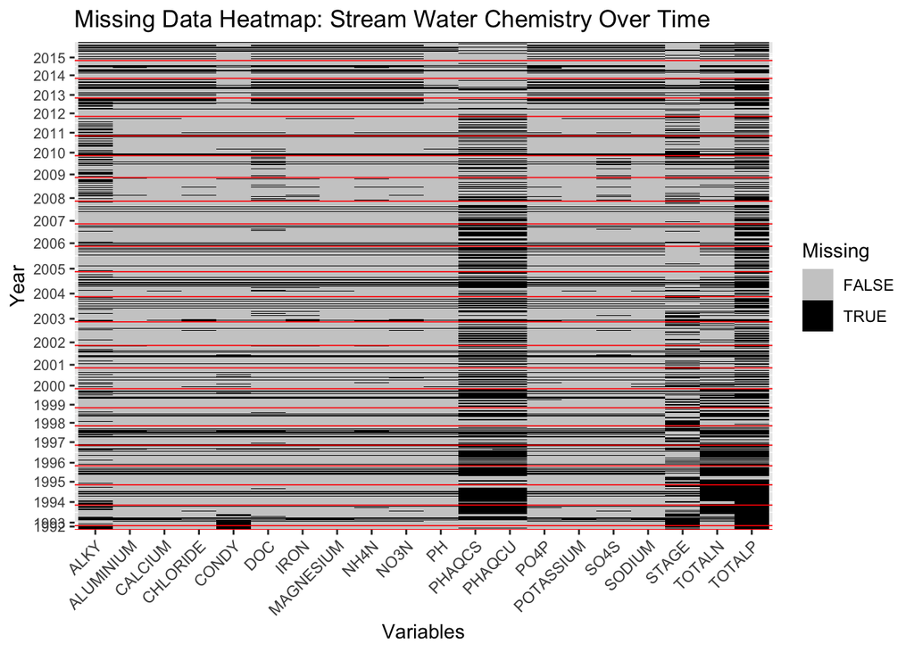

```r
library(tidyverse)

# Stream Water
# Prepare the data for plotting
df_stream_missing <- df_stream_wide %>%
  select(SDATE, where(is.numeric), -LCODE) %>%   # Keep SDATE + numeric columns (drop things like SITECODE), remove LCODE only for the stream water dataframe since it is numeric
  pivot_longer(-SDATE, names_to = "Variables", values_to = "Value") %>%
  mutate(Missing = is.na(Value)) %>%
  arrange(SDATE) %>%
  mutate(Row = as.numeric(factor(SDATE, levels = unique(SDATE))))

# Year break lines for visual clarity
year_breaks_stream <- df_stream_missing %>%
  distinct(SDATE, Row) %>%
  mutate(Year = as.numeric(format(SDATE, "%Y"))) %>%
  group_by(Year) %>%
  summarise(Row = min(Row), .groups = "drop")

# Plot
ggplot(df_stream_missing, aes(x = Variables, y = Row, fill = Missing)) +
  geom_tile(color = NA) +
  scale_fill_manual(values = c("FALSE" = "grey80", "TRUE" = "black")) +
  scale_y_reverse() +
  geom_hline(data = year_breaks_stream, aes(yintercept = Row), color = "red", linewidth = 0.3) +
  scale_y_continuous(
    breaks = year_breaks_stream$Row + 10,  # adjust this based on your density
    labels = year_breaks_stream$Year,
    expand = c(0, 0)
  ) +
  labs(title = "Missing Data Heatmap: Stream Water Chemistry Over Time",
       x = "Variables", y = "Year", fill = "Missing")+
  theme(axis.text.y = element_text(size = 8),
        axis.text.x = element_text(angle = 45, hjust = 1))
```

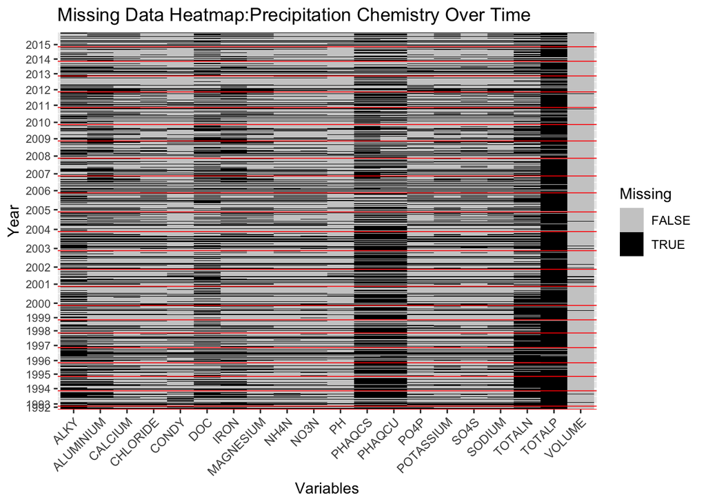

```r
#Same process is used for the other two data frames, copy pasted and changed the df labels
# Precipitation
df_precipitation_missing <- df_precipitation_wide %>%
  select(SDATE, where(is.numeric)) %>%
  pivot_longer(-SDATE, names_to = "Variables", values_to = "Value") %>%
  mutate(Missing = is.na(Value)) %>%
  arrange(SDATE) %>%
  mutate(Row = as.numeric(factor(SDATE, levels = unique(SDATE))))

year_breaks_precipitation <- df_precipitation_missing %>%
  distinct(SDATE, Row) %>%
  mutate(Year = as.numeric(format(SDATE, "%Y"))) %>%
  group_by(Year) %>%
  summarise(Row = min(Row), .groups = "drop")

ggplot(df_precipitation_missing, aes(x = Variables, y = Row, fill = Missing)) +
  geom_tile(color = NA) +
  scale_fill_manual(values = c("FALSE" = "grey80", "TRUE" = "black")) +
  scale_y_reverse() +
  geom_hline(data = year_breaks_precipitation, aes(yintercept = Row), color = "red", linewidth = 0.3) +
  scale_y_continuous(
    breaks = year_breaks_precipitation$Row + 10,
    labels = year_breaks_precipitation$Year,
    expand = c(0, 0)
  ) +
  labs(title = "Missing Data Heatmap:Precipitation Chemistry Over Time",
       x = "Variables", y = "Year", fill = "Missing")+
  theme(axis.text.y = element_text(size = 8),
        axis.text.x = element_text(angle = 45, hjust = 1))
```

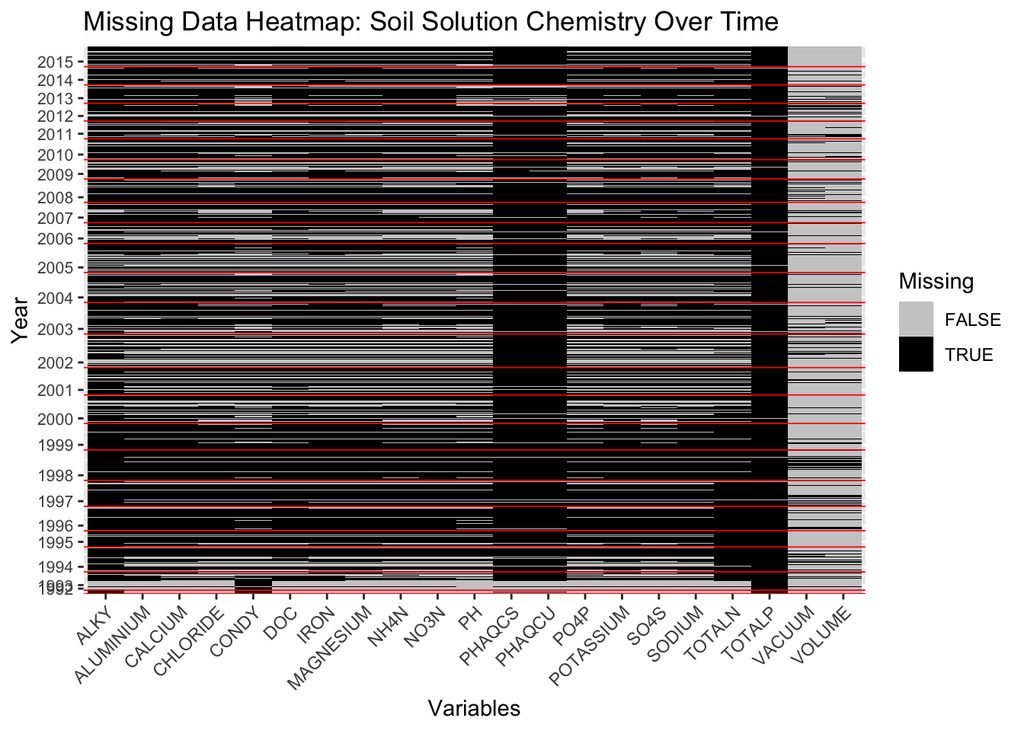

```r
#Soil Solution
df_ss_missing <- df_soil_wide %>%
  select(SDATE, where(is.numeric)) %>%
  pivot_longer(-SDATE, names_to = "Variables", values_to = "Value") %>%
  mutate(Missing = is.na(Value)) %>%
  arrange(SDATE) %>%
  mutate(Row = as.numeric(factor(SDATE, levels = unique(SDATE))))

year_breaks_ss <- df_ss_missing %>%
  distinct(SDATE, Row) %>%
  mutate(Year = as.numeric(format(SDATE, "%Y"))) %>%
  group_by(Year) %>%
  summarise(Row = min(Row), .groups = "drop")

ggplot(df_ss_missing, aes(x = Variables, y = Row, fill = Missing)) +
  geom_tile(color = NA) +
  scale_fill_manual(values = c("FALSE" = "grey80", "TRUE" = "black")) +
  scale_y_reverse() +
  geom_hline(data = year_breaks_ss, aes(yintercept = Row), color = "red", linewidth = 0.3) +
  scale_y_continuous(
    breaks = year_breaks_ss$Row + 10,
    labels = year_breaks_ss$Year,
    expand = c(0, 0)
  ) +
  labs(title = "Missing Data Heatmap: Soil Solution Chemistry Over Time",
       x = "Variables", y = "Year", fill = "Missing")+
  theme(axis.text.y = element_text(size = 8),
        axis.text.x = element_text(angle = 45, hjust = 1))
```

## Stream water

Uniqueness: From the r code to check for the number of duplicated row, we can see that the dataframe has a uniqueness of 100%.

Consistency: consistent

Timeliness: The range is from the 6th of October 1992 to the 31st of December 2015.

Validity: Valid since no out of range value and false formatting was spotted.

Accuracy: Accurate as it matches reality

User needs and trade-offs: Policymakers may want long-term trends to help them make policies. Scientists may need long-term trends to study environmental change, which is critical with regards to climate change.

## Precipitation

Uniqueness: From the r code to check for the number of duplicated row, we can see that the dataframe has a uniqueness of 100%.

Consistency: consistent

Timeliness: The range is from the 6th of October 1992 to the 31st of December 2015.

Validity: Less valid as there exist a negative (-0.32) for the variable of magnesium.

Accuracy: Accurate as it matches reality

User needs and trade-offs: Policymakers may want long-term trends to help them make policies. Scientists may need long-term trends to study environmental change, which is critical with regards to climate change.

Completeness: The data is relatively less complete compared to the stream water data, though there is more grey than black. Overall, the completeness varies across the the years and variables: ALKY (Alkalinity), DOC (Dissolved organic carbon), PHAQCS (Aquacheck system pH stirred), PHAQCU (Aquacheck system pH unstirred), TOTALN (Total nitrogen) and TOTALP (Total dissolved phosphorus) are the variables with the completion, while it is less complete during the first few years of the data, 2003 and, 2013. However, two sets of variables are almost complete, which are: PH (pH) and VOLUME (Volume of sample collected)

## Soil solution

Uniqueness: From the r code to check for the number of duplicated row, we can see that the dataframe has a uniqueness of 100%.

Consistency: consistent

Timeliness: The range is from the 6th of October 1992 to the 23rd of December 2015, which is valid even though it ends earlier compared to the previous dataframes, since this is only sampled fortnightly.

Validity: Valid since no out of range value and false formatting was spotted.

Accuracy: Accurate as it matches reality

User needs and trade-offs: Policymakers may want long-term trends to help them make policies. Scientists may need long-term trends to study environmental change, which is critical with regards to climate change.

Completeness: The data is way less complete in comparison to the previous two comparison, with more black (missing data) than grey (completed data). Overall, the completeness varies across the the years and variables: with PHAQCS (Aquacheck system pH stirred), PHAQCU (Aquacheck system pH unstirred), and TOTALP (Total dissolved phosphorus) barely having any completion, while it has little completion in the second half of 1990s, 2001, 2003, 2008 and 2014-2015. However, two sets of variables are almost complete, which are: VACUUM (Residual vacuum at time of sampling) and VOLUME (Volume of sample collected)

# Step 9: Exploratory Data Analysis (EDA)